# MG-RAST - Metagenome Overview

Richard Sprague

Metagenome Overview

| **MG-RAST ID** | 4633498.3 | Download | Analyze | Search |
| --- | --- | --- | --- | --- |

| **Metagenome Name** | ssr_13603__R1__L001 |
| --- | --- |
| **PI** |  |
| **Organization** |  |
| **Visibility** | Private |
| **Static Link** | http://metagenomics.anl.gov/linkin.cgi?metagenome=4633498.3 |

| **NCBI Project ID** | - |
| --- | --- |
| **GOLD ID** | - |
| **PubMed ID** | - |

### Metagenome Summary

The analysis results shown on this page are computed by MG-RAST. Please note that authors may upload data that they have published their own analysis for, in such cases comparison within the MG-RAST framework can not be done.

[figure not shown]

download data and annotations

[figure not shown]

analyze annotations in detail.

[figure not shown]

search through annotations.

**Sequence Breakdown**

| Description | Sequences |
| --- | --- |
| Failed QC | 2769 |
| Unknown | 0 |
| Unknown Protein | 0 |
| Annotated Protein | 0 |
| ribosomal RNA | 42078 |

*Note: Sequences containing multiple predicted features are only counted in one category.*  
*Currently downloading of sequences via chart slices is not enabeled.*

### Table of Contents

Work with Metagenome Data

- Download
- Analyze
- Search

Overview of Metagenome

- Summary
- GSC MIxS Info

Metagenome QC

- DRISEE
- Kmer Profile
- Nucleotide Histogram

Organism Breakdown

- Taxonomic Distribution
- Rank Abundance Plot
- Rarefaction Curve
- Alpha Diversity

Technical Data

- Statistics
- Metadata
- Source Distribution
- Sequence Length Histogram
- Sequence GC Distribution

### Project Information

This dataset is part of project [Sprague-Jan2015-13603](http://metagenomics.anl.gov/metagenomics.cgi?page=MetagenomeProject&project=13646).

There are 0 other metagenomes in this project

### GSC MIxS Info

- Investigation Typemimarks-survey
- Project Name[Sprague-Jan2015-13603](http://metagenomics.anl.gov/metagenomics.cgi?page=MetagenomeProject&project=13646)
- Latitude and Longitude-, -
- Country and/or Sea, Location-
- Collection Date-
- Environment (Biome)-
- Environment (Feature)-
- Environment (Material)-
- Environmental Package-
- Sequencing Methodillumina
- More Metadata
- » find metagenomes within this project
- » find metagenomes within this biome
- » find metagenomes within this country
- » find metagenomes within 10 | 30 | 100 kilometers

### Analysis Statistics

- Upload: bp Count6,477,024 bp
- Upload: Sequences Count43,577
- Upload: Mean Sequence Length148 ± 15 bp
- Upload: Mean GC percent49 ± 5 %
- Post QC: bp Count4,753,862 bp
- Post QC: Sequences Count40,808
- Post QC: Mean Sequence Length116 ± 30 bp
- Post QC: Mean GC percent54 ± 3 %
- Processed: Predicted rRNA Features946
- Alignment: Identified rRNA Features705

[figure not shown]

### DRISEE [[?]](http://blog.metagenomics.anl.gov/glossary-of-mg-rast-terms-and-concepts/#drisee)

Duplicate Read Inferred Sequencing Error Estimation ([Keegan et al., PLoS Computational Biology, 2012](http://www.ploscompbiol.org/article/info%3Adoi%2F10.1371%2Fjournal.pcbi.1002541))

DRISEE could not produce a profile, this is an Amplicon dataset.

DRISEE is a tool that utilizes artificial duplicate reads (ADRs) to provide a platform independent assessment of sequencing error in metagenomic (or genomic) sequencing data. DRISEE is designed to consider shotgun data. Currently, it is not appropriate for amplicon data.

Note that DRISEE is designed to examine sequencing error in raw whole genome shotgun sequence data. It assumes that adapter and/or barcode sequences have been removed, but that the sequence data have not been modified in any additional way. (e.g.) Assembly or merging, QC based triage or trimming will both reduce DRISEE's ability to provide an accurate assessment of error by removing error before it is analyzed.

### Kmer Profiles [[?]](http://blog.metagenomics.anl.gov/glossary-of-mg-rast-terms-and-concepts/#kmer_profile) hide

Redraw the below plot using the following kmer-plot type:

[figure not shown]

The kmer abundance spectra are tools to summarize the redundancy (repetitiveness) of sequence datasets by counting the number of occurrences of 15 and 6 bp sequences.

The kmer spectrum plots the number of distinct N-bp sequences as a function of coverage level, placing low-coverage (rare) sequences at left and high-coverage, repetitive sequences at right. The kmer rank abundance graph plots the kmer coverage as a function of abundance rank, with the most abundant sequences at left. The ranked kmer consumed graph shows the fraction of the dataset that is explained by the most abundant kmers, as a function of the number of kmers used.

[Download chart data](http://metagenomics.anl.gov/metagenomics.cgi?page=MetagenomeOverview&metagenome=4633498.3&action=chart_export&name=kmer_15_abundance&file=download.4633498.3.kmer_15_abundance)

The image is currently dynamic. To be able to right-click/save the image, please click the static button

[figure not shown]

### Nucleotide Position Histogram [[?]](http://blog.metagenomics.anl.gov/glossary-of-mg-rast-terms-and-concepts/#consensus_plot) hide

These graphs show the fraction of base pairs of each type (A, C, G, T, or ambiguous base "N") at each position starting from the beginning of each read up to the first 151 base pairs. Amplicon datasets should show consensus sequences; shotgun datasets should have roughly equal proportions of basecalls.

[Download chart data](http://metagenomics.anl.gov/metagenomics.cgi?page=MetagenomeOverview&metagenome=4633498.3&action=chart_export&name=consensus_plot&file=download.4633498.3.consensus_plot)

[figure not shown]

| Position | N | G | C | T | A |
| --- | --- | --- | --- | --- | --- |
| 1 | 0.03 | 0.01 | 0.25 | 0.04 | 99.64 |
| 2 | 0 | 0.07 | 99.36 | 0.26 | 0.29 |
| 3 | 0 | 16.89 | 39.81 | 21.93 | 21.34 |
| 4 | 0 | 0.03 | 99.16 | 0.74 | 0.05 |
| 5 | 0 | 0.01 | 1.06 | 98.63 | 0.28 |
| 6 | 0.02 | 0.03 | 98.82 | 1.08 | 0.02 |
| 7 | 0 | 0.15 | 1.31 | 98.27 | 0.25 |
| 8 | 0 | 1.44 | 98.38 | 0.1 | 0.06 |
| 9 | 0 | 99.48 | 0.12 | 0.03 | 0.34 |
| 10 | 0 | 98.24 | 0.13 | 0.06 | 1.55 |
| 11 | 0 | 0.25 | 1.46 | 0.02 | 98.25 |
| 12 | 0 | 1.48 | 98.24 | 0.01 | 0.25 |
| 13 | 0 | 97.56 | 0.25 | 0.05 | 2.11 |
| 14 | 0 | 32.5 | 1.59 | 0.41 | 65.48 |
| 15 | 0 | 1.89 | 96.93 | 0.07 | 1.09 |
| 16 | 0 | 99.55 | 0.28 | 0.04 | 0.11 |
| 17 | 0 | 97.93 | 1.89 | 0.04 | 0.12 |
| 18 | 0 | 3.19 | 96.65 | 0.08 | 0.05 |
| 19 | 0 | 97.19 | 2.28 | 0.37 | 0.14 |
| 20 | 0 | 0.14 | 98.8 | 0.45 | 0.59 |
| 21 | 0 | 0.03 | 97.65 | 1.94 | 0.36 |
| 22 | 0 | 0.05 | 0.21 | 97.49 | 2.23 |
| 23 | 0 | 0.03 | 0.2 | 0.36 | 99.38 |
| 24 | 0 | 0.19 | 1.7 | 1.56 | 96.53 |
| 25 | 0 | 0.66 | 0.24 | 79.68 | 19.4 |
| 26 | 0 | 3.53 | 0.26 | 0.3 | 95.89 |
| 27 | 0 | 97.31 | 1.96 | 0.13 | 0.57 |
| 28 | 0 | 0.47 | 97.93 | 1.2 | 0.38 |
| 29 | 0 | 0.15 | 29.49 | 67.59 | 2.74 |
| 30 | 0.01 | 0.96 | 3.15 | 0.56 | 95.29 |

[output cut: 121 more lines]

### Source Hits Distribution [[?]](http://metagenomics.anl.gov/metagenomics.cgi?page=Sources) hide

42,078 (96.6%) of reads had similarity to ribosomal RNA genes.

The graph below displays the number of features in this dataset that were annotated by the different databases below. These include protein databases, protein databases with functional hierarchy information, and ribosomal RNA databases. The bars representing annotated reads are colored by e-value range. Different databases have different numbers of hits, but can also have different types of annotation data.

There are 15,945,780 sequences in the M5NR protein database and 309,342 sequences in the M5RNA ribosomal database. The M5NR protein database contains all the unique sequences from the below protein databases and the M5RNA ribosomal database contains all the unique sequences from the below ribosomal RNA databases.

[Download chart data](http://metagenomics.anl.gov/metagenomics.cgi?page=MetagenomeOverview&metagenome=4633498.3&action=chart_export&name=source_hits&file=download.4633498.3.source_hits)

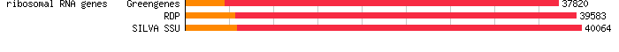

### Taxonomic Hits Distribution hide

The pie charts below illustrate the distribution of taxonomic domains, phyla, and orders for the annotations. Each slice indicates the percentage of reads with predicted proteins and ribosomal RNA genes annotated to the indicated taxonomic level. This information is based on all the annotation source databases used by MG-RAST. An interactive Krona chart of the full taxonomy is also available  
Click on a slice or legend to view all sequences annotated with the indicated taxonomic level in the analysis page.

View taxonomic interactive chart

[output not shown]

[figure not shown]

| domain | Hits |
| --- | --- |
| Archaea | 93 |
| Bacteria | 54836 |
| Eukaryota | 332 |
| Other | 31 |

[output not shown]

[figure not shown]

| phylum | Hits |
| --- | --- |
| Actinobacteria | 751 |
| Arthropoda | 311 |
| Bacteroidetes | 10045 |
| Euryarchaeota | 93 |
| Firmicutes | 41435 |
| Lentisphaerae | 36 |
| Proteobacteria | 30 |
| Streptophyta | 21 |
| Synergistetes | 2 |
| Tenericutes | 1 |
| Verrucomicrobia | 1 |
| unclassified (derived from Bacteria) | 2535 |
| unclassified (derived from unclassified sequences) | 31 |

[output not shown]

[figure not shown]

| class | Hits |
| --- | --- |
| Actinobacteria (class) | 751 |
| Alphaproteobacteria | 1 |
| Bacilli | 182 |
| Bacteroidia | 10032 |
| Betaproteobacteria | 6 |
| Clostridia | 40835 |
| Cytophagia | 1 |
| Erysipelotrichi | 97 |
| Gammaproteobacteria | 23 |
| Insecta | 311 |
| Liliopsida | 17 |
| Methanobacteria | 93 |
| Mollicutes | 1 |
| Negativicutes | 321 |
| Sphingobacteriia | 12 |
| Synergistia | 2 |
| Verrucomicrobiae | 1 |
| unclassified (derived from Bacteria) | 2535 |
| unclassified (derived from Euryarchaeota) | 93 |
| unclassified (derived from Lentisphaerae) | 36 |
| unclassified (derived from Streptophyta) | 4 |
| unclassified (derived from unclassified sequences) | 31 |

[output not shown]

[figure not shown]

| order | Hits |
| --- | --- |
| Acholeplasmatales | 1 |
| Actinomycetales | 20 |
| Bacillales | 29 |
| Bacteroidales | 10032 |
| Bifidobacteriales | 492 |
| Brassicales | 4 |
| Burkholderiales | 6 |
| Chromatiales | 2 |
| Clostridiales | 40824 |
| Coriobacteriales | 239 |
| Cytophagales | 1 |
| Enterobacteriales | 18 |
| Erysipelotrichales | 97 |
| Isoptera | 311 |
| Lactobacillales | 153 |
| Legionellales | 3 |
| Methanobacteriales | 93 |
| Poales | 17 |
| Selenomonadales | 321 |
| Sphingobacteriales | 12 |
| Synergistales | 2 |
| Thermoanaerobacterales | 11 |
| Verrucomicrobiales | 1 |
| unclassified (derived from Alphaproteobacteria) | 1 |
| unclassified (derived from Bacteria) | 2535 |
| unclassified (derived from Euryarchaeota) | 93 |
| unclassified (derived from Lentisphaerae) | 36 |
| unclassified (derived from unclassified sequences) | 31 |

[output not shown]

[figure not shown]

| family | Hits |
| --- | --- |
| Acholeplasmataceae | 1 |
| Acidaminococcaceae | 149 |
| Actinomycetaceae | 3 |
| Aerococcaceae | 4 |
| Alcaligenaceae | 1 |
| Bacillaceae | 26 |
| Bacteroidaceae | 7590 |
| Bifidobacteriaceae | 492 |
| Brassicaceae | 4 |
| Burkholderiaceae | 3 |
| Carnobacteriaceae | 2 |
| Chromatiaceae | 2 |
| Clostridiaceae | 3562 |
| Clostridiales Family XI. Incertae Sedis | 4 |
| Clostridiales Family XVIII. Incertae Sedis | 402 |
| Coriobacteriaceae | 239 |
| Corynebacteriaceae | 16 |
| Cytophagaceae | 1 |
| Enterobacteriaceae | 18 |
| Enterococcaceae | 86 |
| Erysipelotrichaceae | 97 |
| Eubacteriaceae | 4400 |
| Heliobacteriaceae | 6 |
| Lachnospiraceae | 10437 |
| Lactobacillaceae | 36 |
| Legionellaceae | 3 |
| Methanobacteriaceae | 93 |
| Micrococcaceae | 1 |
| Oxalobacteraceae | 2 |
| Paenibacillaceae | 1 |
| Peptococcaceae | 92 |
| Peptostreptococcaceae | 89 |
| Poaceae | 17 |
| Porphyromonadaceae | 1909 |
| Prevotellaceae | 7 |
| Rhinotermitidae | 311 |
| Rikenellaceae | 526 |
| Ruminococcaceae | 18833 |
| Sphingobacteriaceae | 12 |
| Staphylococcaceae | 1 |
| Streptococcaceae | 25 |
| Synergistaceae | 2 |
| Thermoactinomycetaceae | 1 |
| Thermoanaerobacterales Family III. Incertae Sedis | 10 |
| Thermodesulfobiaceae | 1 |
| Veillonellaceae | 172 |
| Verrucomicrobiaceae | 1 |
| Victivallaceae | 36 |
| unclassified (derived from Alphaproteobacteria) | 1 |
| unclassified (derived from Bacteria) | 2535 |
| unclassified (derived from Clostridiales) | 2999 |
| unclassified (derived from Euryarchaeota) | 93 |
| unclassified (derived from unclassified sequences) | 31 |

[output not shown]

[figure not shown]

| genus | Hits |
| --- | --- |
| Abiotrophia | 4 |
| Acetitomaculum | 13 |
| Acetivibrio | 691 |
| Acidaminococcus | 2 |
| Actinomyces | 2 |
| Akkermansia | 1 |
| Alistipes | 526 |
| Allochromatium | 2 |
| Anaerococcus | 1 |
| Anaerostipes | 10 |
| Anaerotruncus | 190 |
| Arthrobacter | 1 |
| Bacillus | 15 |
| Bacteroides | 7590 |
| Barnesiella | 101 |
| Bifidobacterium | 491 |
| Blautia | 6968 |
| Burkholderia | 3 |
| Butyricicoccus | 205 |
| Butyricimonas | 276 |
| Butyrivibrio | 1651 |
| Caldicellulosiruptor | 10 |
| Candidatus Phytoplasma | 1 |
| Cellulosilyticum | 125 |
| Clostridium | 3274 |
| Collinsella | 119 |
| Coprobacillus | 1 |
| Coptotermes | 311 |
| Corynebacterium | 16 |
| Cytophaga | 1 |

[output cut: 67 more lines]

### Rank Abundance Plot hide

Redraw the below plot using the following taxonomic level:

[figure not shown]

The plot below shows the phylum abundances ordered from the most abundant to least abundant. Only the top 50 most abundant are shown. The y-axis plots the abundances of annotations in each phylum on a log scale.

The rank abundance curve is a tool for visually representing taxonomic richness and evenness.

[Download chart data](http://metagenomics.anl.gov/metagenomics.cgi?page=MetagenomeOverview&metagenome=4633498.3&action=chart_export&name=abundance_plot&file=download.4633498.3.abundance_plot)

The image is currently dynamic. To be able to right-click/save the image, please click the static button

[figure not shown]

### Rarefaction Curve hide

[figure not shown]

The plot below shows the rarefaction curve of annotated species richness. This curve is a plot of the total number of distinct species annotations as a function of the number of sequences sampled. On the left, a steep slope indicates that a large fraction of the species diversity remains to be discovered. If the curve becomes flatter to the right, a reasonable number of individuals is sampled: more intensive sampling is likely to yield only few additional species.

Sampling curves generally rise very quickly at first and then level off towards an asymptote as fewer new species are found per unit of individuals collected. These rarefaction curves are calculated from the table of species abundance. The curves represent the average number of different species annotations for subsamples of the the complete dataset.

[Download chart data](http://metagenomics.anl.gov/metagenomics.cgi?page=MetagenomeOverview&metagenome=4633498.3&action=chart_export&name=rarefaction_curve&file=download.4633498.3.rarefaction_curve)

The image is currently dynamic. To be able to right-click/save the image, please click the static button

[figure not shown]

### Alpha Diversity [[?]](http://blog.metagenomics.anl.gov/glossary-of-mg-rast-terms-and-concepts/#alpha_diversity) hide

[figure not shown]

**α-Diversity = 31.330 species**

[figure not shown]

The above image shows the range of α-diversity values in project Sprague-Jan2015-13603. The min, max, and mean values are shown, with the standard deviation ranges (σ and 2σ) in different shades. The α-diversity of this metagenome is shown in red.

Alpha diversity summarizes the diversity of organisms in a sample with a single number. The alpha diversity of annotated samples can be estimated from the distribution of the species-level annotations.

Annotated species richness is the number of distinct species annotations in the combined MG-RAST dataset. Shannon diversity is an abundance-weighted average of the logarithm of the relative abundances of annotated species. The species-level annotations are from all the annotation source databases used by MG-RAST.

[Download source data](http://metagenomics.anl.gov/metagenomics.cgi?page=MetagenomeOverview&metagenome=4633498.3&action=chart_export&name=species_anundance&file=download.4633498.3.species_anundance)

### Sequence Length Histogram hide

The histograms below show the distribution of sequence lengths in basepairs for this metagenome. Each position represents the number of sequences within a length bp range.

The data used in these graphs are based on raw upload and post QC sequences.

[Download chart data](http://metagenomics.anl.gov/metagenomics.cgi?page=MetagenomeOverview&metagenome=4633498.3&action=chart_export&name=upload_len_hist&file=download.4633498.3.upload_len_hist)

The image is currently dynamic. To be able to right-click/save the image, please click the static button

[figure not shown]

[Download chart data](http://metagenomics.anl.gov/metagenomics.cgi?page=MetagenomeOverview&metagenome=4633498.3&action=chart_export&name=postqc_len_hist&file=download.4633498.3.postqc_len_hist)

The image is currently dynamic. To be able to right-click/save the image, please click the static button

[figure not shown]

### Sequence GC Distribution hide

The histograms below show the distribution of the GC percentage for this metagenome. Each position represents the number of sequences within a GC percentage range. The data used in these graphs is based on raw upload and post QC sequences.

[Download chart data](http://metagenomics.anl.gov/metagenomics.cgi?page=MetagenomeOverview&metagenome=4633498.3&action=chart_export&name=upload_gc_hist&file=download.4633498.3.upload_gc_hist)

The image is currently dynamic. To be able to right-click/save the image, please click the static button

[figure not shown]

[Download chart data](http://metagenomics.anl.gov/metagenomics.cgi?page=MetagenomeOverview&metagenome=4633498.3&action=chart_export&name=postqc_gc_hist&file=download.4633498.3.postqc_gc_hist)

The image is currently dynamic. To be able to right-click/save the image, please click the static button

[figure not shown]

### Download This Metagenome

We provide download capabilities for the submitted sequences, metadata, and all files with results that are produced in the process of MG-RAST analysis on the [download page for this metagenome](http://metagenomics.anl.gov/metagenomics.cgi?page=DownloadMetagenome&metagenome=4633498.3). This includes fasta files with annotations using the [M5NR](http://blog.metagenomics.anl.gov/glossary-of-mg-rast-terms-and-concepts/#m5nr).

We also provide access to the blat alignment summaries underlying our sequence analysis work on the [download page](http://metagenomics.anl.gov/metagenomics.cgi?page=DownloadMetagenome&metagenome=4633498.3).

Please note: The graphs on this page allow downloading the underlying information as tables. The search results and most of the pie-charts allow selecting the fraction of sequences in an element to work with in the workbench feature on the [analysis page](http://metagenomics.anl.gov/metagenomics.cgi?page=Analysis&metagenome=4633498.3).

### Analyze This Metagenome

The [analysis page](http://metagenomics.anl.gov/metagenomics.cgi?page=Analysis&metagenome=4633498.3) provides access to analysis and comparative tools including tables, bar charts, trees, principle coordinate analysis, heatmaps and various exports (including FASTA and QIIME). The workbench feature allows sub-selections of data to be used e.g. select all E. coli reads and then display the functional categories present just in E. coli reads across multiple data sets.

### Search This Metagenome

Below searches return all predicted functions or organisms that contain the input text.

### Metadata [[?]](http://blog.metagenomics.anl.gov/glossary-of-mg-rast-terms-and-concepts/#metadata) show